# scNMTseq challenge analysis using a PLS-based approach

Al JalalAbadi[^1]

11 Aug 2020

**Note:** These analyses are different from the ones presented in the hackathon due to updated preprocessing if data in order to harmonize the analyses for publication. For original analyses see https://github.com/ajabadi/scNMT_seq_gastrulation.

Load the required packages:

```r
library(BIRSBIO2020.scNMTseq.PLS)
library(MultiAssayExperiment)
library(scater)
library(scran)
library(mixOmics)
library(ggplot2)
library(magrittr)
library(reshape2)
```

# Data

Details of the hackathon data and preprocessing steps: https://github.com/BIRSBiointegration/Hackathon/tree/master/scNMT-seq

Load the `MultiAssayExperiment` object from Cloudstor:

```r
cat('loading data from Cloudstor ...\n')
```

```
#> loading data from Cloudstor ...
```

```r
gastru.mae_path <- url('https://cloudstor.aarnet.edu.au/plus/s/jsW7nh4YwThw8Q5/download')
```

```r
gastru.mae <- readRDS(gastru.mae_path)
```

## Filter MAE object

```r
# Subset RNA expression and DNA methylation modalities
keep_assays <- grep("rna|met",names(assays(gastru.mae)))
# Remove putative extraembryonic cells
keep_cells <- !(gastru.mae$lineage %in% params$drop_lineages)
# Keep cells that pass QC for DNA methylation and RNA expression
keep_cells <- keep_cells & (gastru.mae$pass_metQC==TRUE & gastru.mae$pass_rnaQC==TRUE)
## keep full rna SCE for UMAP
rna.sce <- gastru.mae@ExperimentList$rna
## subset MAE
gastru.mae <- gastru.mae[,keep_cells, keep_assays]
```

```
#> harmonizing input:
#>   removing 3768 sampleMap rows not in names(experiments)
## rna SCE for matching cells
```

```r
rna.sce.matching <- gastru.mae@ExperimentList$rna
```

Replace the rna SCE with logcounts in MAE object as the integration wrapper requires matrices in assays:

```r
gastru.mae@ExperimentList
```

```
#> ExperimentList class object of length 5:
#>  [1] rna: SingleCellExperiment with 18345 rows and 942 columns
#>  [2] met_genebody: matrix with 17559 rows and 942 columns
#>  [3] met_promoter: matrix with 17179 rows and 942 columns
#>  [4] met_cgi: matrix with 14080 rows and 942 columns
#>  [5] met_DHS: matrix with 6673 rows and 942 columns
```

```r
gastru.mae@ExperimentList$rna <- logcounts(gastru.mae@ExperimentList$rna)
```

Overview of assays:

```r
get_pct_missing <- function(arr) {
  round(100*sum(is.na(arr))/prod(dim(arr)))
}

df <- lapply(experiments(gastru.mae), function(w)
     {
     c(
       'N (# cells)' = dim(w)[2],
       'P (# features)' = dim(w)[1],
       '% data missing' = get_pct_missing(w)
     )
     })
df <- data.frame(df)
kable(t(df), align = 'l')
```

|  | N (# cells) | P (# features) | % data missing |
| --- | --- | --- | --- |
| rna | 942 | 18345 | 0 |
| met_genebody | 942 | 17559 | 20 |
| met_promoter | 942 | 17179 | 36 |
| met_cgi | 942 | 14080 | 47 |
| met_DHS | 942 | 6673 | 61 |

Breakdown of the number of cells in each stage:

```r
table(gastru.mae$stage) %>% as.data.frame() %>% t() %>% set_rownames(c('stage', '# of cells')) %>% kable()
```

| stage | E4.5 | E5.5 | E6.5 | E7.5 |
| --- | --- | --- | --- | --- |
| # of cells | 107 | 110 | 351 | 374 |

```r
## create a data.frame from cell metadata
coldata <- data.frame(colData(gastru.mae))
```

## Feature detection

Create density plots of the feature detection rate across all cells for all modalities:

```r
# get the methylation assays
met_assays <- grep(names(gastru.mae), pattern = '^met', value = TRUE)
# add dimensions to labels for ggplot
dims <- lapply(experiments(gastru.mae[,,met_assays]), dim)
dims <- sapply(dims, function(x) sprintf(' (%s, %s)', x[2], x[1]))
names(met_assays) <- paste0(met_assays, dims) %>% as.list()
# calculate the feature detection in a data.frame for methylation assays
coverages <- lapply(met_assays, function(assay_name) {
  mat <- assay(gastru.mae, assay_name)
  NAs <- rowSums(!is.na(mat))/dim(mat)[2]*100
  data.frame(pct_NAs=NAs)
})
# create a long data.frame containing the assay name for plot
coverages <- rbindListWithNames(coverages)
coverages$dataset <- factor(coverages$dataset, levels = unique(coverages$dataset), ordered = TRUE)
```

Genomic contexts vary in level of feature detection rates:

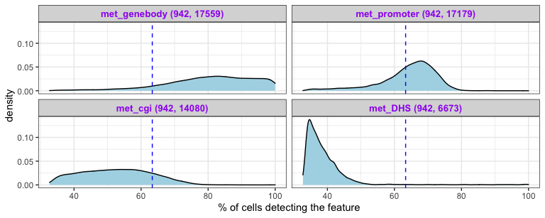

```r
cov_plot <- ggplot(coverages, aes(x = pct_NAs)) + geom_density(fill = 'lightblue', show.legend = FALSE) +
  geom_vline(aes(xintercept=mean(pct_NAs)),
             color="blue", linetype="dashed", size=0.5) +
  labs(x = '% of cells detecting the feature') + facet_wrap(.~dataset, nrow = 2) +
  theme_bw() + theme(strip.text.x = element_text(size = 10, face = 'bold', color = 'purple'))

cov_plot
```

Density plots for methylation data show that shorter genomic regions tend to have less feature coverage. Dashed blue line indicates the average across all modalities.

# RNA

## UMAP

```r
# Create colour palettes for stages:
# col_pallete <-dput( viridisLite::viridis(n = 4) )
col_pallete <- c("#440154FF", "#31688EFF", "#35B779FF", "#FDE725FF")
names(col_pallete) <- c("E4.5", "E5.5", "E6.5", "E7.5")

## helper function to create UMAP plots coloured by stage
plot_umap_by_stage <- function(df, dims = c(1,2)) {
  axes <- paste0('UMAP_', dims)
  ggplot(df, aes_string(axes[1], axes[2])) + geom_point(aes(col=stage)) +
    theme_classic()+ scale_color_manual(values = col_pallete) + labs(col = 'Stage')
}
```

### All RNA cells

Select highly variable genes after accounting for technical variation:

```r
decomp <- modelGeneVar(rna.sce)
## filter by mean expression and significance of biological variation signal
hvgs <- rownames(decomp)[decomp$p.value<0.01 & decomp$mean > 0.01]
length(hvgs)
```

```
#> [1] 381
```

Run PCA and then UMAP using PCs:

```r
## PCA first: retrieve 25 PCs
rna.sce <- runPCA(rna.sce,  ncomponents = 25, subset_row=hvgs)

RNGversion('4.0.0')
set.seed(params$umap_params['run.seed'])
rna.sce <- runUMAP(rna.sce, dimred="PCA",
                   ncomponents = params$umap_params['n_components'],
                   n_neighbors = params$umap_params['n_neighbors'],
                   min_dist = params$umap_params['min_dist'])
```

data.frame of embeddings with cell metadata:

```r
# data.frame of embeddings with cell metadata
df <-  data.frame(reducedDim(rna.sce,"UMAP"))
colnames(df) <- paste0('UMAP_', seq_along(df))
df <- cbind(df, colData(rna.sce))
```

Plot the first two UMAP components:

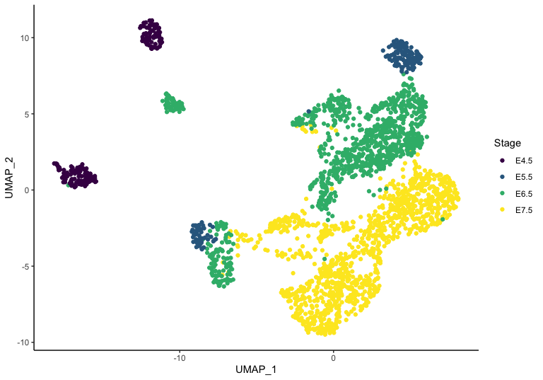

```r
plot_umap_by_stage(df = df, dims = c(1,2))
```

UMAP plot shows distinct cell populations corresponding to early-stage, mid-stage, and late-stage cells as well as the within-stage variation for mainly E4.5 and E6.5 which could correspond to different lineages.

### Matching RNA cells

Select highly variable genes after accounting for technical variation:

```r
decomp <- modelGeneVar(rna.sce.matching)
## filter by mean expression and significance of biological variation signal
hvgs <- rownames(decomp)[decomp$p.value<0.01 & decomp$mean > 0.01]
length(hvgs)
```

```
#> [1] 474
```

Run PCA and then UMAP using PCs:

```r
## PCA first: retrieve 25 PCs
rna.sce.matching <- runPCA(rna.sce.matching,  ncomponents = 25, subset_row=hvgs)

RNGversion('4.0.0')
set.seed(params$umap_params['run.seed'])
rna.sce.matching <- runUMAP(rna.sce.matching, dimred="PCA",
                   ncomponents = params$umap_params['n_components'],
                   n_neighbors = params$umap_params['n_neighbors'],
                   min_dist = params$umap_params['min_dist'])
```

data.frame of embeddings with cell metadata:

```r
# data.frame of embeddings with cell metadata
df <-  data.frame(reducedDim(rna.sce.matching,"UMAP"))
colnames(df) <- paste0('UMAP_', seq_along(df))
df <- cbind(df, colData(rna.sce.matching))
```

Plot the first two UMAP components:

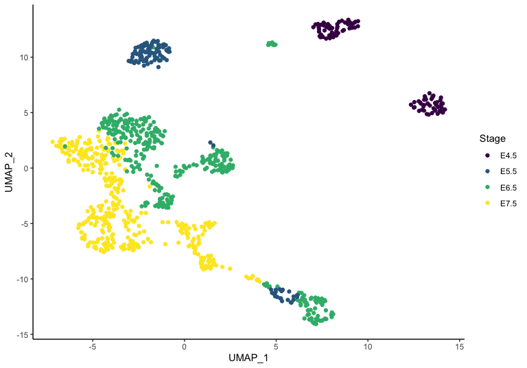

```r
plot_umap_by_stage(df = df, dims = c(1,2))
```

# Integration

## PLS

data dimensions overview:

```r
# data dimensions
lapply(experiments(gastru.mae), dim)
```

```
#> $rna
#> [1] 18345   942
#>
#> $met_genebody
#> [1] 17559   942
#>
#> $met_promoter
#> [1] 17179   942
#>
#> $met_cgi
#> [1] 14080   942
#>
#> $met_DHS
#> [1] 6673  942
```

integration of all modalities with feature selection:

```r
## number of components
ncomp <- 2
## feature scaling
scale <- TRUE
```

Here we select for 50 features on each component in `multimodal_sPLS_wrapper`:

```r
cat(sprintf('Running PLS with %s components performing variable selection\n', ncomp))
```

```
#> Running PLS with 2 components performing variable selection
```

```r
st <- system.time({
  mmspls <-
    multimodal_sPLS_wrapper(mae = gastru.mae, study_assays = NULL,
                            ncomp = ncomp, scale = TRUE, design = 'null', lineages = NULL,
                            stages = NULL, DA = NULL, keepX = NULL, save = FALSE)
})['elapsed']
```

```
#> Making unique feature names by adding assay name to feature name for: met_genebody
#> Making unique feature names by adding assay name to feature name for: met_promoter
#> Warning in cor(A[[k]], variates.A[[k]]): the standard deviation is zero
```

```r
st <- round(st/60, 1)

cat('\nPLS run finished. Runtime: ', st, 'min\n')
```

```
#>
#> PLS run finished. Runtime:  1.1 min
```

```r
plotIndiv_wrapper <- function(pls_obj, coldata, col_cell = 'stage', legend.title = 'Stage', comp = c(1,2), ...) {
  ## order coldata cells based on matching cells in pls modalities
  coldata <- coldata[rownames(pls_obj$X[[1]]),]
  cell_class <- coldata[,col_cell]  ## col factor for cells
  cell_class <- factor(cell_class)
  suppressWarnings({
    plotIndiv(pls_obj, pch = 16, comp = comp,group = cell_class, legend = TRUE, legend.title = legend.title, size.subtitle = 10, cex=0.8, ...)
  })
}
```

## score plots

Colored by stage:

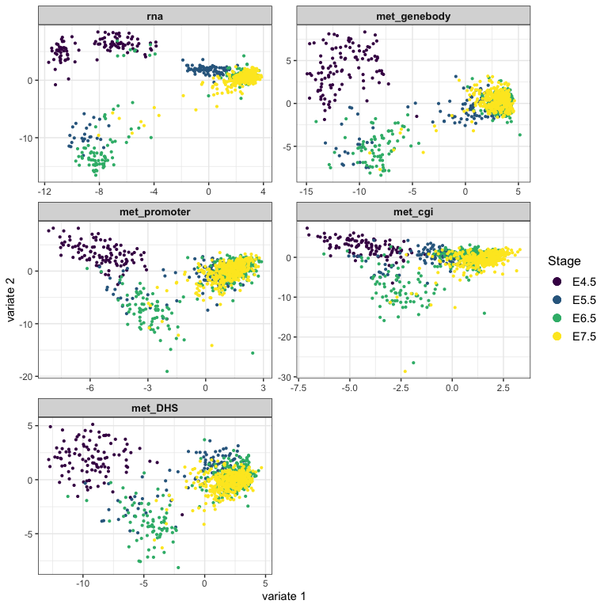

```r
plotIndiv_wrapper(pls_obj = mmspls, coldata = coldata, col_cell = 'stage', legend.title = 'Stage', comp = c(1,2), subtitle = names(mmspls$X), col.per.group = col_pallete)
```

# concordance with RNA

Here we calculate the correlations between components from gene expression and different methylome modalities:

```r
concordance <- function(pls_obj, comp = 1) {

  ## correlation of components with RNA components
  cor_with_y <- sapply(pls_obj$variates[-1], function(x_variates) {
    y_variates <- pls_obj$variates[[1]]
    y_variates <- y_variates[, comp, drop = FALSE]
    cor <- cor(y_variates, x_variates)
    cor <- diag(cor)
    names(cor) <- paste0('Component ', comp)
    cor['mean'] <- mean(cor)
    cor <- round(cor, 2)
    cor
  })
  ## make a long data.frame
  cor_with_y <- cor_with_y %>% as.data.frame() %>% t() %>%
    reshape2::melt(id.vars = 1:3) %>%
    set_colnames(c('Modality', 'Component', 'Concordance'))
  ## print concordance measures for each componet and the average:
  # sapply(unique(as.character(cor_with_y$Component)), function(z){
  #   cat('#> Component:', z )
  #   dplyr::filter(cor_with_y, Component == z)[,c('Modality', 'Concordance')] %>%
  #     kable()
  # })

  ggplot(cor_with_y, aes(x = Modality, y = Concordance)) + geom_col(aes(fill = Component), position = 'dodge2') + theme_classic() +
    labs(y = sprintf('Correlation with RNA (comp %s) ', paste(comp, collapse = ', ')), x = '', fill = '') + ylim(c(0, 1)) + theme(axis.text.x = element_text(angle = 45, vjust = 0.8, hjust=1))
}
```

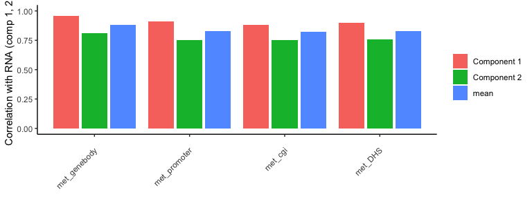

```r
concordance(pls_obj = mmspls, comp = c(1, 2))
```

[^1]: Melbourne Integrative Genomics, The University of Melbourne (al.jal.abadi@gmail.com)